# Group Assignment #3

Group 5

13/5/2020

### Task

We want to explore the differences between the Orbis universe of German firms and the firms that filed for Insolvency in July and August. In order to do so, we perform three different steps. First, we limit the insolvency sample to firms who filed for insolvency. Second, we merge these firms algorithmically with the firms from the Orbis universe. Thereby, we are facing multiple issues that will be described below. Third, we define a set of informative variables to compare the insolvent firms with the others.

### Step 1: Identifing firms that filed for insolvency in July and August

Read the data (following Joachim Gassen https://github.com/joachim-gassen/vhb_qear20/blob/master/code/describe_insolvency_data.Rmd).

```r
insol_raw <- read_csv(
  "../raw_data/insolvency_filings_de_julaug2020.csv",
  col_types = cols()
)
```

Select firms who filed for insolvency in July and August and delete duplicates.

```r
insol_op <- insol_raw %>%
  filter(subject == "Eröffnungen") %>%
  unique()
```

Check for missing values in insolvency data (following Joachim Gassen https://github.com/joachim-gassen/vhb_qear20/blob/master/code/describe_insolvency_data.Rmd).

```r
na_vals <- insol_op %>%
  summarise_all(list( ~ sum(is.na(.))))

nas_df <- tibble(
  Variable = names(insol_op),
  `NA count` = t(na_vals)
)

kable(nas_df) %>%
  kable_styling(full_width = FALSE)
```

| Variable | NA count |
| --- | --- |
| date | 0 |
| insolvency_court | 0 |
| court_file_number | 0 |
| subject | 0 |
| name_debtor | 0 |
| domicile_debtor | 0 |

That’s nice! We do not have missing values. Therefore, we are now interested in how many firms actually filed for insolvency.

```r
nrow(insol_op)
```

```
## [1] 1044
```

### Step 2: Merging insolvency data with data from orbis universe

After having identified all firms that filed for insolvency, we want to merge them with the Orbis data. Therefore, we first need to load the data (following Joachim Gassen https://github.com/joachim-gassen/vhb_qear20/blob/master/code/describe_insolvency_data.Rmd).

```r
orbis_raw <- read_csv(
  "../raw_data/orbis_wrds_de.csv",
  col_types = cols()
)
```

As the Orbis data starts in the 90s, we want to restrict the observations to more recent periods. Therefore, we select only observations after 2015 and delete duplicates.

```r
orbis_de <- orbis_raw %>%
  filter(year > "2015") %>%
  unique()
```

In order to match the data with the insolvency data, we need to identify a key variable. As the insolvency data only contains the name of the filing firms, we need to rely on firm names for matching. This is not without problems because normally names are very noisy. Additionally, we should check whether every firms filed only once for insolvency (following Joachim Gassen https://github.com/joachim-gassen/vhb_qear20/blob/master/code/describe_insolvency_data.Rmd).

```r
unique_firms <- insol_op %>%
  distinct(name_debtor, .keep_all = TRUE)

unique_firms %>%
  group_by(insolvency_court, court_file_number) %>%
  filter(n() > 1) %>%
  arrange(insolvency_court, court_file_number, name_debtor) %>%
  kable() %>%
  kable_styling()
```

| date | insolvency_court | court_file_number | subject | name_debtor | domicile_debtor |
| --- | --- | --- | --- | --- | --- |
| 2020-08-04 | Ingolstadt | IN 164/20 | Eröffnungen | BJC Best Job IT Services GmbH | Hamburg |
| 2020-08-03 | Ingolstadt | IN 164/20 | Eröffnungen | BJC Best Job Services GmbH | Hamburg |
| 2020-08-27 | Königstein/Ts. | 90 IN 33/20 | Eröffnungen | Springer Management Consultants vertr. d.d. Aufsichtsrat | Königstein im Taunus |
| 2020-08-07 | Königstein/Ts. | 90 IN 33/20 | Eröffnungen | Springer Management Consultants vertr. d.d. Vorstand | Königstein im Taunus |

As we can see, there are two firms who filed for insolvency twice. While one wonder how this might come, it sould not bother our analysis because we are only interested in whether the firm filed or not.

##### Merging strategy

In order to merge both data sets based on firm names, we try to build a key variable which is less noisy against common speeling variations. Therefore, we create a new variable which is named “key” in both datasets which contains modified names by deleting white spaces, removing punctuation and transforming letters to lower cases.

```r
insolvency <- insol_op %>%
  mutate(key = name_debtor)

insolvency$key <- gsub("[[:space:]]", "", insolvency$key)
insolvency$key <- gsub("[[:punct:]]", "", insolvency$key)
insolvency$key <- tolower(insolvency$key)

orbis <- orbis_de %>%
  mutate(key = name_native)

orbis$key <- gsub("[[:space:]]", "", orbis$key)
orbis$key <- gsub("[[:punct:]]", "", orbis$key)
orbis$key <- tolower(orbis$key)
```

After creating the keys, we can merge both datasets with a left join. Additionally, we are creating a dummy variable “insolvency” which is 1 in the case of insolvency filing and 0 otherwise.

```r
merged_data <- left_join(orbis, insolvency, by = "key")

merged_data$insolvency <- ifelse(merged_data$subject == "Eröffnungen", 1, 0)
merged_data$insolvency[is.na(merged_data$insolvency)] <- 0
```

Delete unneeded variables.

```r
merged_data  <- merged_data  %>%
  select(-X1, -ctryiso, -key, -name_debtor)
```

Now, we want to explore for how many firms the merge was successfull.

```r
table(merged_data$insolvency)
```

```
##
##      0      1
## 889012    508
```

```r
matched_cases <- merged_data %>%
  filter(insolvency == "1") %>%
  group_by(name_native) %>%
  count()
nrow(matched_cases)
```

```
## [1] 270
```

```r
merged_data %>%
  filter(insolvency == "1") %>%
  group_by(name_native)%>%
  count() %>%
  arrange(desc(n))%>%
  kable() %>%
  kable_styling()
```

name_native

n

Phoenix GmbH

12

Kuhn GmbH

7

Roth GmbH & Co. KG

7

Zeitgeist GmbH

5

AC Consulting GmbH

4

BMS - Stahlbau GmbH

4

H. P. Gauff Ingenieure GmbH & Co. KG - JBG -

4

MyTime Cologne GmbH

4

On Stage Studio 1 GmbH

4

OPTIMUM GmbH

4

Poppe GmbH

4

SEC GmbH

4

serva transport systems GmbH

4

Sinn GmbH

4

Zeiher GmbH

4

EBS GmbH

3

Esprit Design & Product Development GmbH

3

Esprit Wholesale GmbH

3

FINOBA Automotive GmbH

3

HGS GmbH

3

Minda KTSN Plastic Solutions GmbH & Co. KG

3

“TRAILS” Natur- und Erlebnisreisen GmbH

2

>>DOVO<< Stahlwaren BRACHT GmbH & Co. KG

2

6. Fondis Real Estate GmbH

2

Adolf und Robert Zimmermann GmbH & Co. KG

2

All in One Personalservice GmbH

2

Alten- und Pflegeheim Landhaus Sonnenhalde GmbH

2

Angela Beteiligungsgesellschaft mbH

2

aviare consult GmbH

2

AY Transporte, Import & Export GmbH

2

AZS Anzeigenblatt Zustell-Service Lippe GmbH

2

B+L Anlagenbau GmbH & Co. KG

2

Bals Bau GmbH

2

Bau & Montage Dresden GmbH

2

Baubetreuung GmbH & Co. KG

2

Bauunternehmung Martin Limbrecht GmbH & Co. KG

2

Bergschneider Gastro GmbH

2

Betterlighting Vertriebs GmbH

2

Bioline GmbH

2

BiteBox GmbH

2

Bogen Electronic GmbH

2

Brocks GmbH

2

BXR IndustrieService GmbH & Co. KG

2

C 3 Kliniken Aachen GmbH

2

C 3 Kliniken Dortmund GmbH

2

C 3 Kliniken Duisburg GmbH

2

C 3 Kliniken Essen GmbH

2

C 3 Kliniken Holding GmbH

2

Calakovic Estriche GmbH

2

CCA Contextuelle CoachingAcademie GmbH

2

Cicekler Logistik GmbH

2

CIM-BASE GmbH Consulting und Engineering

2

D & O Werbe- und Vertriebs-Service GmbH

2

DAF-Bau GmbH

2

DI Bau GmbH

2

Dichtungsservice Feindt GmbH

2

Die Hand-in-Hand-Werker GmbH

2

Dilber Wohnbau GmbH

2

Dr. Hahner & Albrecht Verwaltungs GmbH

2

Dr. Z Beteiligungs- und Verwaltungs GmbH

2

Dr. Z Medizinisches Versorgungszentrum GmbH

2

Druckerei Eisenhardt GmbH

2

Edwin Kestler GmbH

2

Ekowep Verwaltungs-GmbH

2

Elbe Immobilien GmbH

2

Elektrohaus Kurzer GmbH

2

Esprit Europe GmbH

2

Esprit Europe Services GmbH

2

Esprit Retail B.V. & Co. KG

2

Fashion Store GmbH & Co. KG

2

FDD GmbH

2

First WISE Media GmbH

2

FLABEG Deutschland GmbH

2

Flensburger Schiffbau-Gesellschaft m.b.H. & Co. KG

2

Fotosatz Nord Druck- und Verlagsgesellschaft mbH

2

Fritz Gross GmbH

2

Gasteig Kult und Speise GmbH

2

Genesys International GmbH

2

GRAFIMEX Grafische Maschinen, Materialien und Ersatzteile Exportgesellschaft mbH

2

Hallhuber GmbH

2

Heckhaus GmbH & Co. KG

2

HEIBO Logistics Services GmbH

2

Helmut Gernet GmbH

2

Herzberger-Logistik-Partner GmbH

2

Hierl Naturkost GmbH

2

Hotel Eisenhut GmbH & Co. KG

2

IBC GmbH

2

IMS Internationaler Marketing-Service GmbH

2

Intermeet Fashion Administrations- und Import GmbH

2

Iventas live GmbH

2

J & R Beteiligungs GmbH

2

JR Beteiligungs GmbH

2

JTM Sportnahrung GmbH

2

JTW Reisen GmbH

2

K & R Vermittlungs GmbH

2

k2werk GmbH

2

Karl Hesmer GmbH Werkzeug- und Maschinenfabrik

2

KC Beteiligungs GmbH

2

Kino Colosseum Betriebsgesellschaft mbH

2

KJ-Modulbau GmbH & Co. KG

2

Klinik Zimmermann Betriebsgesellschaft mbH

2

KLW Transport GmbH

2

Korn-Klischee GmbH

2

KR-Bauelemente GmbH & Co. KG

2

Krankenhaus 14 Nothelfer GmbH

2

Kunst und Kollegen Kommunikationsagentur GmbH

2

La Famiglia Proetto GmbH & Co. KG

2

La Famiglia Proetto Verwaltungs GmbH

2

LED Connect Group GmbH

2

Ligas-Tischlerarbeiten GmbH

2

LRT Kurierdienst GmbH

2

Malatesta GmbH & Co. KG

2

MANNS Ingenieure GmbH

2

MarLen Truck-Styling GmbH

2

MarMadura Schiffahrtsgesellschaft mbH & Co. KG

2

MarMisool Schiffahrtsgesellschaft mbH & Co. KG

2

Mayer Schneid- und Umformtechnik GmbH

2

Meikamp GmbH

2

Metallgestaltungs GmbH

2

MICE access GmbH

2

Minit Service GmbH

2

MPR Gastro GmbH

2

MyCleaner GmbH

2

Nagel Auktionen GmbH & Co. KG

2

Navitas Life Sciences GmbH

2

Neues Transpla Haar GmbH

2

Niederrheinische Maschinenfabrik Kleve GmbH

2

Niggemeyer Bildproduktion GmbH & Co. KG

2

NOBA-Fliesen GmbH

2

Nordpunkt-Trans GmbH

2

NRW Lift Aufzugsbau GmbH

2

Omega Automotive Gmbh

2

Oschmann Comfortbetten GmbH

2

OSRI Food GmbH

2

P R O C O M GmbH

2

PDM Formenbau GmbH

2

Pearlcars Autovermietung GmbH

2

PHOENIX GmbH

2

planhaus Pankow GmbH

2

Pluradent Aktiengesellschaft

2

Poggenpohl Forum GmbH

2

pomodoro communications GmbH

2

preStep GmbH

2

ProCom GmbH

2

PZS Presse-Zustellservice GmbH Bad Salzuflen

2

PZS Presse-Zustellservice GmbH Detmold

2

RECYLEX GmbH

2

Redzepi GmbH Betonstahlverlegung

2

ReMass GmbH & Co. KG

2

Ritter Maschinenbau GmbH

2

RK Beteiligungs-GmbH

2

Roth Catering GmbH

2

Samtec GmbH

2

Sarar Retail GmbH

2

SCHACO foamtec GmbH

2

Schwemmle Bauunternehmen GmbH

2

Seniorenresidenz Dietenhofen GmbH

2

SMTCL Deutschland GmbH

2

So1 GmbH

2

Somnia Hospitality & Consulting GmbH

2

Spargel Paul GmbH & Co. KG

2

Sparky GmbH

2

SPARKY Power Tools GmbH

2

Sporthaus Eisert GmbH

2

Stageservice Frankfurt am Main GmbH

2

SUN PROMOTIONS GmbH

2

sun.factory Deutschland GmbH

2

Support Q GmbH

2

ten have GmbH

2

Thermocolor Vertriebs GmbH

2

TIS Technischer Industrie Service GmbH & Co. KG

2

TOM TAILOR Holding SE

2

Tom Travel GmbH

2

Transport Service Hartwig GmbH

2

Triton Werft Jacobs Formstahl GmbH

2

TTS Sports GmbH

2

Vischer GmbH

2

VOL-Vertriebs-Gesellschaft Ostwestfalen-Lippe GmbH

2

VS Logistics Services Verden GmbH

2

Wailandt’sche Druckerei Aschaffenburg GmbH & Co. KG

2

Wan Jia Le GmbH

2

WD Transporte Internationale Spedition GmbH

2

Werner-Niemetz GmbH & Co. Garten- und Landschaftsbau KG

2

WIES Fensterbau GmbH

2

Wild Kunststofftechnik GmbH

2

Wilken Metalltechnik GmbH & Co. KG

2

WKS Kaufhaus GmbH

2

ACE Automaten GmbH

1

AL Aktuelles aus Leverkusen GmbH

1

Andy Wedelich Zimmermeister GmbH & Co. KG

1

Apalis GmbH

1

Bau-Tech GmbH

1

Bergarbeiter-Krankenhaus Schneeberg g GmbH

1

Bierschneider Bauunternehmen GmbH

1

Bio Power GmbH & Co. KG

1

BJC Best Job IT Services GmbH

1

BRANDO-4 Bekleidungseinzelhandels GmbH

1

BRR Becker-Rohstoff-Recycling GmbH & Co. KG

1

C2P Germany GmbH

1

CID Solution GmbH

1

Ciminello Bau GmbH

1

CoBe Capital Advisors GmbH

1

concept1 GmbH

1

D & F GmbH

1

Deller GmbH

1

DEU-FEN GmbH

1

Dieter Sauter Rolladen- und Fensterbau GmbH & Co. KG

1

ELOG Systembetrieb GmbH

1

emkon Systemtechnik, Projektmanagement GmbH

1

EMTEL GmbH

1

FairMont GmbH

1

Fidelis Express 24 GmbH

1

FLABEG Automotive Holding GmbH

1

FLB Tech GmbH

1

Flensburger Schiffbau-Gesellschaft m.b.H.

1

Fresh Vitamin Handels GmbH

1

GIT Gesellschaft industrieller Technologien mbH

1

GM Global Fair GmbH

1

GMH Guss GmbH

1

Graeber & Partner Fachpersonal GmbH

1

H und C Restaurant Betriebs GmbH

1

Harz-Metall GmbH

1

Horizn Studios GmbH

1

Hot Dog Factory GmbH

1

INLICO International Lifestyle Cooperative eG

1

Johanne Meineke Ww. GmbH

1

Jung & Alt GmbH Ambulante Pflegedienste

1

Karlie GmbH

1

Karosserie Balzer GmbH

1

Karstadt Feinkost GmbH & Co. KG

1

KC Beteiligungs-GmbH

1

KFD Krankenfahrdienst Schwaben GmbH

1

KIKI Bau GmbH

1

Kommanditgesellschaft Schuh Kay (GmbH & Co.)

1

KubeOne GmbH

1

KUG Ingenieure GmbH & Co.KG

1

LGS Logistik GmbH

1

Maginvest GmbH

1

Microtherm GmbH

1

NORD - EXPRESS Transport GmbH

1

Nordport Plaza Hotel Betriebs-GmbH

1

optimum gmbh

1

Optimum GmbH

1

Parfois Germany GmbH

1

Petersdorf GmbH

1

PPM Pure Metals GmbH

1

PPS. Imaging GmbH

1

PSB Event Consulting GmbH

1

QMN Quality Management Nord GmbH

1

Ramon Koch GmbH

1

RESPITEC GmbH

1

RibWich Food-Trucks GmbH

1

RK Beteiligungs GmbH

1

Romaker Transporte GmbH

1

SARAR EUROPE GmbH

1

schmidt consult & travel GmbH

1

Schwabe & Baer Entwicklungs GmbH

1

SHAPES GmbH

1

SITBU Bahndienste GmbH

1

Stadtwaldresidenz GmbH

1

Terra-Tec GmbH

1

TIMA Investment GmbH & Co. KG

1

TK YPSILON GmbH

1

triple-A-toys GmbH

1

TS Immobau GmbH

1

VAD-Bau GmbH

1

VAD Bau GmbH

1

W. Bockstiegel GmbH & Co. Reederei KG MS “BBC Arizona”

1

Wirecard Communication Services GmbH

1

Yilmaz Bewehrungstechnik GmbH

1

### Step 3: Informative variables to compare the insolvent firms with solvent firms.

#### We start with some basic descriptive tables showing the different characteristics of solvent and insolvent firms.

The following tables demonstrate the observations by industry. While Other Services amount for most observations in the solvent and insolvent subsample, followed by Wholesale and construction industry, the transport and metal product industry account for over 5% of insolvent cases. Especially, Food, beverages and tobacco, as well as, Wood, cork, paper, and Gas, Water, Electricity industries show the fewest cases of insolvency in our sample.

```r
d.summary <- sumtable1 %>%
    select(industry=rowname, Freq, '% Total') %>%
    print()
```

```
## # A tibble: 17 x 3
##    industry                                            Freq `% Total`
##    <chr>                                              <dbl>     <dbl>
##  1 Other services                                       169    33.3
##  2 Wholesale & retail trade                             108    21.3
##  3 Construction                                          48     9.45
##  4 Transport                                             35     6.89
##  5 Metals & metal products                               27     5.31
##  6 Education, Health                                     25     4.92
##  7 Hotels & restaurants                                  25     4.92
##  8 Machinery, equipment, furniture, recycling            20     3.94
##  9 Chemicals, rubber, plastics, non-metallic products    15     2.95
## 10 Publishing, printing                                  12     2.36
## 11 Post & telecommunications                              9     1.77
## 12 Textiles, wearing apparel, leather                     9     1.77
## 13 Gas, Water, Electricity                                3     0.591
## 14 Wood, cork, paper                                      2     0.394
## 15 Food, beverages, tobacco                               1     0.197
## 16 <NA>                                                   0     0
## 17 Total                                                508   100
```

```r
d.summary <- sumtable2 %>%
    select(industry=rowname, Freq, '% Total') %>%
    print()
```

```
## # A tibble: 21 x 3
##    industry                                            Freq `% Total`
##    <chr>                                              <dbl>     <dbl>
##  1 Other services                                      4665     38.5
##  2 Wholesale & retail trade                            2854     23.6
##  3 Construction                                        1018      8.41
##  4 Machinery, equipment, furniture, recycling           857      7.08
##  5 Primary sector                                       439      3.62
##  6 Metals & metal products                              406      3.35
##  7 Chemicals, rubber, plastics, non-metallic products   290      2.39
##  8 Hotels & restaurants                                 278      2.30
##  9 Transport                                            267      2.20
## 10 Gas, Water, Electricity                              261      2.16
## # ... with 11 more rows
```

#### Based on the paper by Beaver et. al (2012) we decided to calcualte the following determinants:

1. Profitability: Calculated by ROA
2. Loss year: Indicator for negative ROA in 2018
3. Leverage: Calculated by total liabilities / Total assets
4. Size: Calculated as ln of total assets
5. Profitability: Calculated by ROA (Should we use lagged toas?)

```r
merged_data$roa <- merged_data$pl / merged_data$toas
```

2. Loss year: Indicator for negative ROA in 2018

```r
merged_data$loss <- ifelse(merged_data$roa < 0, 1, 0)
```

3. Leverage: Calculated by total liabilities / total assets

```r
merged_data$lta <- (merged_data$ncli + merged_data$culi) / merged_data$toas
```

4. Size: Calculated as ln of total assets

```r
merged_data$lntoas <- log(merged_data$toas)
```

Look at distribution of size

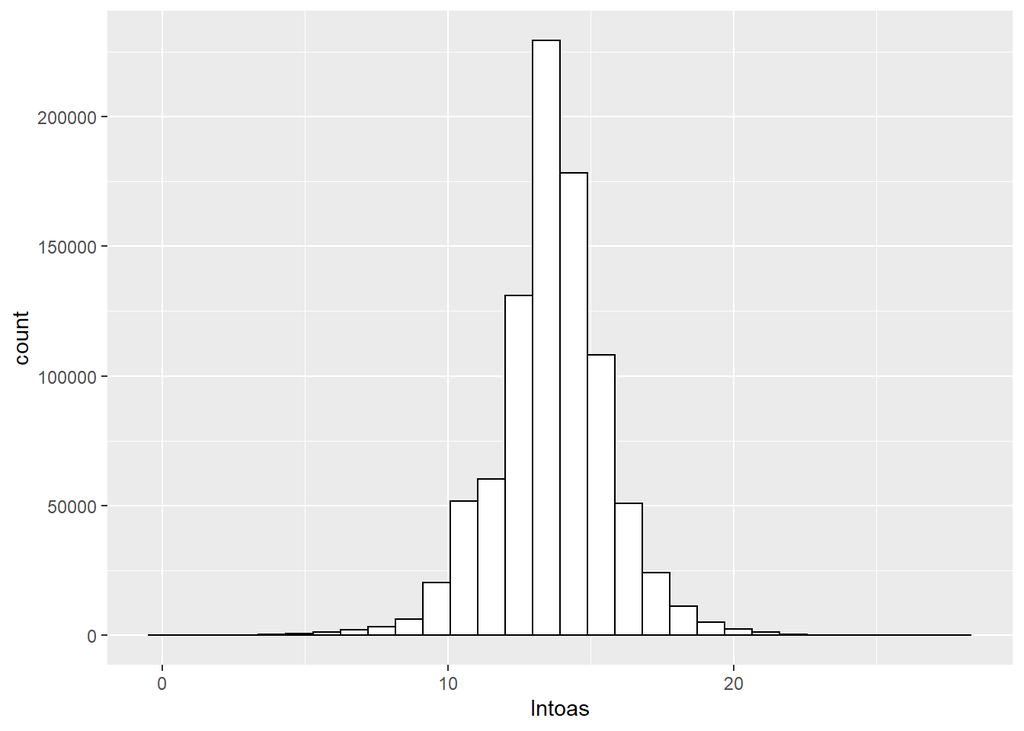

```r
ggplot(merged_data, aes(x=lntoas)) +
    geom_histogram(colour="black", fill="white")
```

Quick check how many non missing values we have for the different determinants.

```r
sum( !is.na( merged_data$roa ) )
```

```
## [1] 60273
```

```r
sum( !is.na( merged_data$loss ) )
```

```
## [1] 60273
```

```r
sum( !is.na( merged_data$lta ) )
```

```
## [1] 889518
```

```r
sum( !is.na( merged_data$lntoas ) )
```

```
## [1] 889520
```

Summary statistics of solvent and insolvent firms

```r
d.summary <- d.summary.extended %>%
    select(var=rowname, min, median, max, mean, sd) %>%
    print()
```

```
## # A tibble: 5 x 6
##   var           min      median     max      mean           sd
##   <chr>       <dbl>       <dbl>   <dbl>     <dbl>        <dbl>
## 1 cash   -2318772   111774      1.69e11 2399995.  270088482.
## 2 roa      -75356        0.0368 5.73e 6      92.9     23349.
## 3 lta         -12.9      0.634  1.69e 7      44.6     18729.
## 4 lntoas        0       13.6    2.78e 1      13.6         2.01
## 5 empl          1       12      6.64e 5      83.0      2677.
```